# Statistical Methods for Reliability Data

Chapter 2 - Models, Censoring, and Likelihood for Failure-Time Data

W. Q. Meeker, L. A. Escobar, and J. K. Freels

29 June 2018

# OVERVIEW

## This Chapter Explains...

- Models for continuous failure-time processes
- Models used for the discrete data from these continuous failure-time processes
- Common censoring mechanisms that restrict our ability to observe all of the failure times that might occur in a reliability study
- Principles of likelihood and how likelihood relates to the probability of the observed data
- How likelihood ideas can be used to make inferences from reliability data

# 2.1.1 - Failure Time Distribution Functions

## Overview of Probability Functions

- The `probability_functions` app from the `teachingApps` package includes the six probability functions used most in reliability studies and highlights:
  - Expressions for each function
  - Mathematical relationships between the functions
  - How to compute values for each function in R - for a variety of distributions
- The most current published version of the `teachingApps` package can be installed from CRAN by pasting the code below into the R console

```r
install.packages('teachingApps')
```

- The development version of the `teachingApps` package (which may contain some newer features) can be installed from GitHub by pasting the code below into the R console

```r
if(!'devtools'%in%installed.packages()[,1]) {

   install.packages('devtools')

  }

devtools::install_github('Auburngrads/teachingApps')
```

- Once the package is installed, the app can be rendered by pasting the code below into the R console

```r
teachingApps::teachingApp('probability_functions')
```

## Figure 2.1 Distribution Plots For $T \sim WEIB(1.7,1)$

- The text introduces the probability functions using the $WEIB(1.7,1)$ distribution as an example and illustrates four functions in Figure 2.1
- The SMRD package includes the `distribution plot( )` function, that can be used to reproduce this figure or similar figures for many other distributions
  - If single values are given for both parameters `distribution.plot( )` returns a plot showing $F(t), f(t), S(t)$ and $h(t)$
  - If multiple values are given for either parameter `distribution.plot( )` returns a plot showing $F(t), f(t), h(t)$ and a legend of the parameter values displayed

[figure not shown]

```r
par(family = 'serif',font = 2)

library(package = SMRD)

distribution.plot('Weibull',
                  shape = c(1.7),
                  scale = 1,
                  prob.range = c(.000001,.99))
```

- Focusing on the plot of the CDF in this figure, we can recreate this plot by itself using either `base` R graphics or using the `ggplot2` package as follows
  - First, we create two vectors representing the `x` and `y` coordinates for each point in the plot.
  - Next, we create the plot using `base` graphics with the `plot` function
  - Then, we create this using `ggplot2` graphics with the `ggplot` function. Note that `ggplot` requires the data to be stored as a `data.frame`

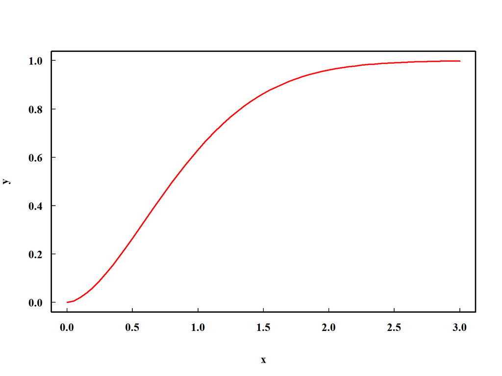

```r
x <- seq(0,3, by = 0.05)
y <- pweibull(x, shape = 1.7, scale = 1)

plot(x = x,
     y = y,
     type = 'l',
     lwd = 2,
     col = 'red',
     las = 1)
```

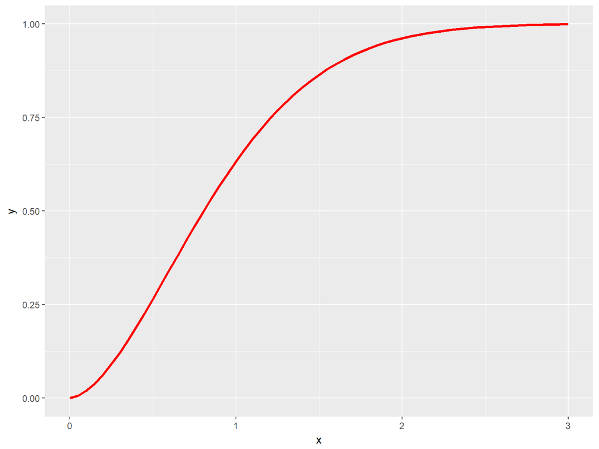

```r
library(ggplot2)

df <- data.frame(x, y)

ggplot(df) +
  geom_line(aes(x = x, y = y), size = 1.1, colour = 'red')
```

# 2.2 - MODELS FOR DISCRETE DATA FROM A CONTINUOUS PROCESS

## Understanding failure

- Failure implies that a product's ability to perform one or more functions has been either...
  - Lost completely, or
  - Degraded to the point that the product cannot meet a performance specification
- When failure occurs in fielded systems, there may not be an immediate indication to the user or the maintainers
  - Some component and sub-component failures may only be discovered after a subsystem or the entire system fails
  - Component failures in complex systems can remain undiscovered until the next inspection cycle
  - Because of this, inspection intervals should be short enough to allow maintainers multiple opportunities to discover flaws and prevent serious failures
  - Inspection intervals should be long enough to not overburden maintainers with unnecessary inspections
- In real-world testing, we typically cannot observe the exact failure time for every unit in the sample
  - Testing may occur in different geographic regions
  - Sample size may be too large
  - Test items may be removed from a test to fill a "real-world" need
  - The test period may end before every item fails
  - Items may fail before the first inspection

# 2.2.1 - Multinomial Failure Time Model

## Real world reliability data

- We can't constantly monitor the performance of every component when a system is in the field.
- For this reason real-world failure data are often reported as the inspection time when the failures were observed
- Thus, real-world failure data are often reported as DISCRETE values corresponding to the inspection cycle
- This occurs even if the sample space for the data is continuous $\Omega \in \mathbb{R}$
- To analyze this real-world failure data appropriately, we partition the test into non-overlapping intervals corresponding to the time between inspections, i.e.
  $$(t_0,t_1], (t_1,t_2],...,(t_{m-1},t_m],(t_m,t_{m+1}),\;\;\;\;\; t_0=0, t_{m+1}=\infty$$
- The intervals do not need to be of equal length
  - Inspections may be made more frequently at the beginning of a test to check for "infant mortality" failures or ensure that the test was set-up correctly
  - Inspections may then become less frequent once the "bad actors" have been culled from the population

## Multinomial Reliability Estimation

- Estimating reliability in this scenario is similar to estmating the likelihood of a single $n$-sided die landing on a specific number
- However, in the context of failure data the 'sides' refer to the $n$ inspection intervals
- Think about how to estimate the probability of a 6-sided die landing on a given side
  - If the die is 'fair' and we rolled it many times (i.e. $n \gtrsim 10,000$ rolls) we would expect that in the long-run
    $$\frac{\text{# times we roll 1,2,3,4,5,6}}{\text{# of total rolls}}\rightarrow P(X=1,2,3,4,5,6) = \frac{1}{6}$$
  - However, if $n$ is much smaller, say 100 rolls, the probability that the die lands on a given side is modeled using the multinomial distrubution with probability mass function
    $$f(n,\pi_{_{1}},...,\pi_{_{m+1}}|d_{_{1}},...,d_{_{m+1}})=\frac{n!}{d_1!,...,d_{m+1}!}\pi_{_{1}}^{d_{1}},...,\pi_{_{m+1}}^{d_{m+1}}$$
- In the context of rolling a single die with $m+1$ sides, the variables in this equation represent
  - $n$ - number of rolls
  - $d_1,...,d_{m+1}$ - number of times each of the faces $1,...,m+1$ are observed
  - $\pi_{_{1}},...,\pi_{_{m+1}}$ - the long-run probabilities of observing faces $1,...,m+1$
- In the context of failures occuring in $m+1$ discrete time intervals, these variables represent
  - $n$ - the number of systems under test
  - $d_{1}$ - number of systems that failed in the $1^{st}$ interval $(t_{0},t_{1}]$
  - $d_{2}$ - number of systems that failed in the $2^{nd}$ interval $(t_{1},t_{2}]$
  - $d_{m+1}$ - number of systems still operating at the final inspection $(t_{m},\infty)$
  - $\pi_{_{i}},...,\pi_{_{m+1}}$ - the long-run probability that a unit will fail in interval $i,...,m+1$

## Figure 2.5 - Relationship between $\pi_{i}$ and $F(t)$

- For a fair die and a fair toss we say that $\pi_1=\pi_2=\pi_3=\pi_4=\pi_5=\pi_6 \approx 1/6$
  - The value $1/6$ is the propensity of the overall EXPERIMENT, and is a function of how the die was manufactured AND how it was tossed
  - Think of it as the underlying physical dynamics that govern the likelihood of observing a given result
  - A "weighted" die would have a different propensity represented by different values of $\pi_1\ne\pi_2\ne\pi_3\ne\pi_4\ne\pi_5\ne\pi_6$
  - Likewise, with some practice we might be able to toss the die in such a way as to affect the propensity
- For systems under test, the propensity is a complex relationship between the system's probability of failure and the environment in which it operates
- For the simplest case, $\pi_{i}=P(t_{i-1}<T\le t_{i})=F(t_{i})-F(t_{i-1})$, where
  - $\pi_i\ge 0, \forall i$
  - $\displaystyle \sum_{j=1}^{m+1}\pi_j=1$
  - $F(t)$ is the underlying failure time distribution relating the likelihood of failure at some time $t$
- Figure 2.5 illustrates the relationship between $\pi_{i}$ and $F(t)$, where the underlying failure time distribution is assumed to be $Weibull(1.7,1)$

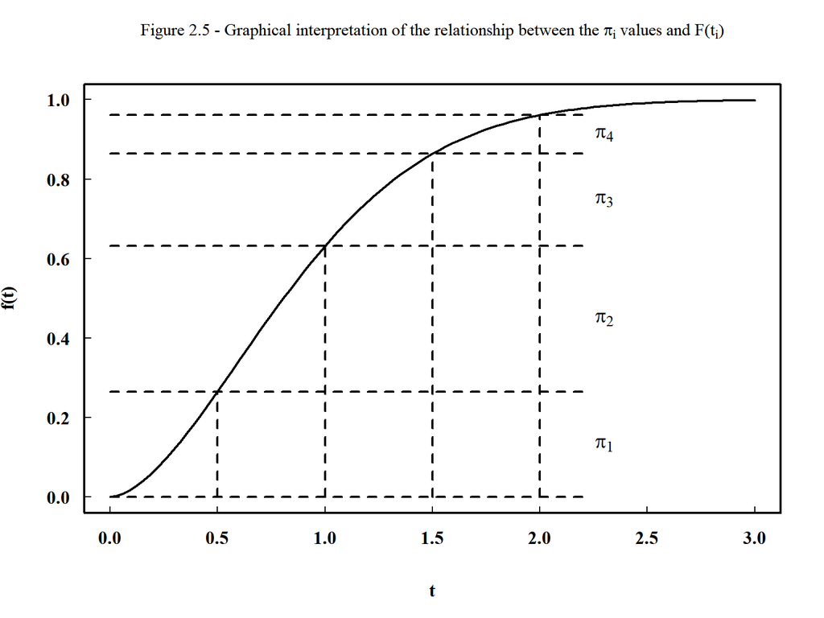

Figure 2.5 - Graphical interpretation of the relationship between the $pi_{i}$ values and $F(t_{i})$

```r
par(family = 'serif', font = 2)

y <- function(t) { pweibull(t,shape = 1.7,scale = 1) }

curve(pweibull(x,shape=1.7,scale=1),lwd = 2,
      xlab = 't', ylab = 'f(t)',
      from = 0, to = 3,
      las = 1)

segments(c(0,.5,1,1.5,2,rep(0,5)),
         c(rep(0,5),y(c(0.01,.5,1,1.5,2))),
         c(0,.5,1,1.5,2,rep(2.2,5)),
         rep(y(c(0.01,.5,1,1.5,2)),2),
         lty=rep(2,10),col=rep(1,10))

text(2.3,(y(0.5)+y(.01))/2,expression(pi[1]),cex=1.25)
text(2.3,(y(1.0)+y(0.5))/2,expression(pi[2]),cex=1.25)
text(2.3,(y(1.5)+y(1.0))/2,expression(pi[3]),cex=1.25)
text(2.3,(y(2.0)+y(1.5))/2,expression(pi[4]),cex=1.25)

mtext(side = 3,
      expression('Figure 2.5 - Graphical interpretation of the relationship between the '*pi[i]*' values and F('*t[i]*')'),
      font = 2,line = 2)
```

## Multinomial Survival Function

- Based on this definition of $F(t_{i})$, the survival function evaluated at $t_{i}$ may be expressed as

$$S(t_i)=P(T>t_i)=1-F(t_i)=\sum_{j=i+1}^{m+1}\pi_j$$

- Where
  - $i$ denotes the inspection of interest
  - $j$ denotes an arbitrary inspection $j \ne i$
- In words, this equation states that the probability that a system will survive to inspection $i$ is equal to the sum of the probabilities that the system will fail at inspection $i+1$ or later

# Multinomial Failure Time Model - In-Class Example

## Conditional Multinomial Distribution Function

- Motivation for this example
  - Many A/C components cannot be inspected by base-level Mx due to lack of training, facilities, tools, etc.
  - Components will only be inspected every $t$ flight-hours at the depot
  - For each component, $\exists$ an underlying $F(t), t\in \mathbb{R}^{+}$ describing time to failure
  - The form of $F(t)$ is often unknown, but may sometimes be inferred from similar components/systems
- Goal of this example
  - Estimate risk of delaying replacement until next inspection (depot cycle)
  - Balance safety risks against replacement costs
- Estimating the risk of delaying replacement until the next inspection implies that
  - The system was still operating at inspection $i-1$
  - We want to know how likely it is that the system will fail before inspection $i$
  - The text defines this quantity in (2.7) as $p_{i}$
  - $p_{i}$ is the conditional probability that the system will fail prior to inspection $i$, given that it has survived to inspection $i-1$.
    $$p_i=P(t_{i-1}<T\le t_{i}|T>t_{i-1})=\frac{F(t_i)-F(t_{i-1})}{1-F(t_{i-1})}=\frac{\pi_{i}}{S(t_{i-1})}$$

# 2.2.2 - Multinomial CDF

## Multinomial Survival Function and CDF

- From Equation 2.7 we can define the survival function in terms of $\mathbf{p}=(p_{1},...,p_{m})$ as
  $$\displaystyle S(t_{i})=\prod_{j=1}^{i}[1-p_{j}], i=1,...,m+1.$$
- It follows that the CDF is expressed as
  $$\begin{aligned}
  F(t_{i})&=1-\prod_{j=1}^{i}[1-p_{j}], i=1,...,m+1 \\
  &=1-\prod_{j=1}^{i} 1-\frac{F(t_i)-F(t_{i-1})}{1-F(t_{i-1})}\\
  &=1-\prod_{j=1}^{i} \frac{1-F(t_{i-1})}{1-F(t_{i-1})}-\frac{F(t_i)-F(t_{i-1})}{1-F(t_{i-1})}\\
  &=1-\prod_{j=1}^{i} \frac{1 - F(t_i)}{1-F(t_{i-1})}\\
  &=1-\prod_{j=1}^{i} \frac{S(t_i)}{S(t_{i-1})}\\
  &=\sum_{j=1}^{i}\pi_{j}
  \end{aligned}$$
- How would you state the final expression in this equation IN WORDS

# 2.2.2 - Multinomial CDF - Example 2.8

## Computing of $F(t_i), S(t_i), \pi_i$ and $p_i$

- Table 2.1 shows the resulting values for our example in which the underlying failure time distribution is $WEIB(1.7,1)$
- The following steps show how the values in the table were computed for the first and second inspections

| **$i$** | **$t_{i}$** | **$F(t_{i})$** | **$S(t_{i})$** | **$\pi_{i}$** | **$p_{i}$** | **$1-p_{i}$** |
| --- | --- | --- | --- | --- | --- | --- |
| 0 | 0.0 | 0.000 | 1.000 |  |  |  |
| 1 | 0.5 | 0.265 | 0.735 | 0.265 | 0.265 | 0.735 |
| 2 | 1.0 | 0.632 | 0.368 | 0.367 | 0.500 | 0.500 |
| 3 | 1.5 | 0.864 | 0.136 | 0.231 | 0.629 | 0.371 |
| 4 | 2.0 | 0.961 | .0388 | .0967 | 0.715 | 0.285 |
| 5 | $\infty$ | 1.000 | .0000 | .0388 | 1.000 | 0.000 |
|  |  |  |  | **1.000** |  |  |

- At the first inspection $t_{1}=0.5$
  $$\begin{aligned}
  F(0.5)&=1-\exp\left[-\left(\frac{0.5}{1}\right)^{1.7}\right]=\underline{0.2649275}\\\\\\
  S(0.5)&=1-F(0.5)=\underline{0.7350725}\\\\\\
  \pi_i&=F(t_i)-F(t_{i-1})=F(0.5)-F(0)=\underline{0.2649275}\\\\\\
  p_i&=\frac{\pi_i}{S(t_{i-1})}=\frac{F(0.5)-F(0)}{S(0)}=\frac{0.2649275}{1}=\underline{0.2649275}
  \end{aligned}$$
- At the second inspection $t_{2}=1.0$
  $$\begin{aligned}
  F(1)&=1-\exp\left[-\left(\frac{1}{1}\right)^{1.7}\right]=\underline{0.6321206}\\\\\\
  S(1)&=1-F(1)=\underline{0.3678794}\\\\\\
  \pi_i&=F(t_i)-F(t_{i-1})=F(1)-F(0.5)=\underline{0.3671931}\\\\\\
  p_i&=\frac{\pi_i}{S(t_{i-1})}=\frac{F(1)-F(0.5)}{S(0.5)}=\frac{0.3671931}{0.7350725}=\underline{0.4995331}
  \end{aligned}$$

# 2.3 - CENSORING

## Types of censoring

- Observe the event plots shown in the figure below
- The event plot on the left shows the `lfp1370` data set in the `SMRD` package
- The event plot on the right shows the `turbine` data set in the `SMRD` package
- What type of testing do you think would produce each of these event plots?

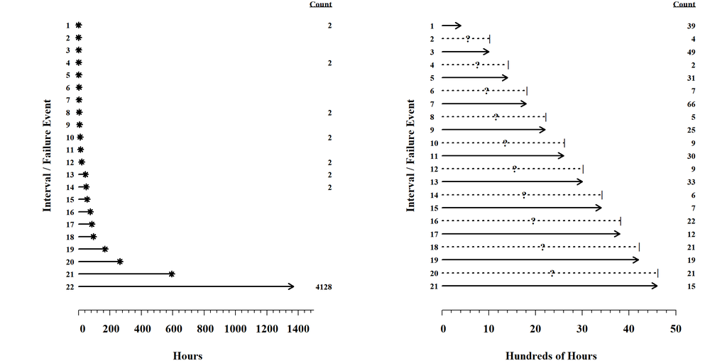

Event plots for the `lfp1370` (left) and `turbine` (right) datasets

```r
library(SMRD)

lfp1370.ld <-
frame.to.ld(SMRD::lfp1370,
            response.column = 1,
            censor.column = 2,
            case.weight.column = 3,
            time.units = 'Hours')

turbine.ld <-
frame.to.ld(SMRD::turbine,
            response.column = 1,
            censor.column = 2,
            case.weight.column = 3,
            time.units = 'Hundreds of Hours')

par(mfrow = c(1,2),family = 'serif',font = 2)

event.plot(lfp1370.ld)
event.plot(turbine.ld)
```

# 2.3.1 - Censoring Mechanisms

## Types of Right Censoring

- **Type I (Time) Censoring** - Occurs when time considerations limit our ability to observe the exact failure times of one or more samples
  - The total available test time is predetermined before testing begins
  - Samples still operating after the predetermined end of testing are Type-I right-censored
  - In this type of test, the number of observed failures is a random quantity
  - There's no guarantee that any failures will be observed before testing ends
- **Type II (Failure) Censoring** - Occurs when time considerations limit our ability to observe the exact failure times of one or more samples
  - The number of observed failures is predetermined before testing begins
  - Samples still operating after the predetermined number of failures have been observed are Type-II right-censored
  - In this type of test the total test time is a random quantity
  - There's no guarantee a sufficient number of failures will be observed in a reasonable timeframe
- Modeling Type II censored data is simpler than for Type I censored data
- Failure censored tests (Type II) are far less common than time-censored tests
- Why would these two statements be true?

## Time censored data may be further divided according to

- **The number of censoring events**
  - Singly censored
  - Multiply censored
- **The contribution to the likelihood function $\S$ 2.4**
  - Right censored
  - Left censored
  - Interval censored
- Remember...ALL DATA IS INTERVAL DATA

# 2.3.2 - Important Assumptions On Censoring Mechanisms

## Independent vs. Dependent Censoring

- This course considers censoring events that are **independent** of the time to failure
  - The time at which testing ends is driven by real-world constraints - not because we want to ensure the test ends before an item fails
  - Inspections should not be delayed so that a longer lifetime can be reported
  - Items should not be removed from a test because it appears that they are 'about to fail'
- Competing risks considers **dependent** censoring events that affect time to failure
  - Dependent censoring is common in medical survivability research
  - Dependent censoring is beyond the scope of this course

# 2.3.2 - Important Assumptions On Censoring Mechanisms - Example

## Independent vs. Dependent Censoring

- Suppose we're investigating the time to recurrence of symptoms in cancer patients who receive a new experimental treatment
- Further suppose that the two patients described below are involved in our study
  - Patient A moves away during the study - we can't collect any future observations
  - Patient B is killed in a car crash during the study - we can't collect any future observations
- How should we handle the data we've already collected for these patients?
  - The last observation for Patient A would be independently right censored because there's a positive probability that the cancer symptoms could return - even though we may not be able to observe when they returned
  - The data observed for Patient B is an example dependent censoring because there is zero probability that the cancer symptoms could return

# 2.4 - LIKELIHOOD

## The Likelihood Function $\mathscr{L}(\theta|\mathbf{y})$ And The PDF $f(\mathbf{y}|\theta)$

- Suppose we want to simulate 50 observations from a specified distribution to use for an example
- How would we do it?
  1. We'd first have to choose a distribution family to simulate from (log-normal, Weibull, exponential)
  2. We'd then choose a set of parameter values to indicate the specific member of our chosen distribution family
  3. Finally, we'd use a software application to generate 50 random observations using the distribution/parameter set we chose
- So, let's simulate 50 failure observations in the interval $[50,150]$ using the following distributions
  - $LOGNOR(\mu = 4.5, \sigma = 0.2)$  
    `rlnorm(n = 50, meanlog = 4.5, sdlog = 0.2)`
  - $WEIB(\beta = 5.5, \eta = 120)$  
    `rweibull(n = 50, shape = 5.5, scale = 120)`
  - $EXP(\theta = 40)$  
    `rexp(n = 50, rate = 1/40)`
- The parameter values in each of these distributions were chosen to generate observations between $50$ and $150$

## Observing data patterns

- Paste the code in the chunk below in R to bring up the shiny app
- The app shows the result of our simulation in two separate plots

```r
teachingApps::teachingApp('data_patterns')
```

- The left plot
  - Shows the pdfs of each distribution along with the 50 failure times simulated from each distribution
  - When the observations are plotted this way, it's easy to see how the distributions differ
- The right plot
  - Shows the raw observations ordered from smallest to largest
  - In this plot we can see that the observations simulated from the exponential distribution are skewed toward lower values compared to the Weibull and lognormal distributions
  - However, it's much harder to distinguish between the observations from the Weibull and lognormal distributions.

## What's The Point?

- Specifying the distribution family and parameter values gives information about the pattern of the data that will result from the simulation
  - Sometimes, it's easy to distinguish different patterns, just by looking at the data visually
  - More often, graphical and numerical methods are required to distinguish between the patterns of data produced by different distributions
  - Simulating more observations can sometimes make it easier to distinguish between the patterns
- But the opposite should be true as well
  - The data should also provide information about the distribution family and parameter values that were most likely to have produced them
  - Again, sometimes it's easy to pick out what distribution family produced a data set just by looking at the pattern of the data
  - If more observations are available, it becomes easier to distinguish which distribution family produced the data
  - In most cases, numerical methods are needed to distinguish which distribution produced a data set
  - A popular numerical method of extracting information from data to identify which probability distribution is most likely to have produced it is Maximum Likelihood Estimation

# 2.4.1 - Likelihood-Based Statistical Methods

## Background

- Suppose that we observe $DATA = y_{1},y_{2},...,y_{n}$ from a test event
- If these observations were produced by units that can reasonably be considered as identical, then we can say that
  $$y_{1},y_{2},...,y_{n} \sim F(y|\mathbf{\theta}=\theta_{1},...,\theta_{n})$$
- However, the true form of $F(y|\mathbf{\theta})$ and values of $\theta_{1},...,\theta_{n}$ are unknown
- Likelihood theory states that for each distribution family, we can find $\mathbf{\theta}$ such that the negative log of the joint probability of the data is minimized, that is
  $$\boldsymbol{\hat{\theta^*}}
  = \underset{\boldsymbol{\theta} \in \boldsymbol \Theta}{\text{arg}\;\min} \bigg(-\log\bigg[\Pr(y_1,\ldots,y_n|\boldsymbol{\theta})\bigg]\bigg)$$
- If these observations are mutually independent, this joint probability can be stated as

$$\begin{aligned}
\boldsymbol{\hat{\theta^*}} &= \underset{\boldsymbol{\theta} \in \boldsymbol \Theta}{\text{arg}\;\min} \bigg(-\log\bigg[\prod_{i=1}^{n}\Pr(y_{i}|\boldsymbol{\theta})\bigg]\bigg)\\\\
&= \underset{\boldsymbol{\theta} \in \boldsymbol \Theta}{\text{arg}\;\min} \bigg(-\sum_{i=1}^{n}\log\bigg[\Pr(y_{i}|\boldsymbol{\theta})\bigg]\bigg)\\\\
\end{aligned}$$

- This joint probability is a loss function in $\theta$ defined over the interval $[0,+\infty)$
- Under what circumstance would this loss function equal $0$?

## Maximum likelihood estimation

- The joint probability defined above $\Pr(y_1,\ldots,y_n|\boldsymbol{\theta})$ is also known as the Likelihood Function and is denoted by $\mathscr{L}(\boldsymbol{\theta|y_1,\ldots,y_n)}$, thus for observation $i$
  $$\mathscr{L}(\mathbf{\theta}|y_i)=\Pr(y_i|\mathbf{\theta})$$
- Note that
  - $\mathscr{L}(\theta|y_i)$ is a function of the parameter vector $\theta$ for a given observation $y_i$
  - $\Pr(y_{i}|\theta)$ is a function of the observed values $y_i$ for a given parameter vector $\theta$
- For a vector of observations, $y_1,\ldots,y_n$, the total likelihood is expressed as
  $$\mathscr{L}(\boldsymbol{\theta}|y_1,\ldots,y_n)=C\prod_{i=1}^{n} \mathscr{L}(\theta|y_i)=\prod_{i=1}^{n}\Pr(t_{i}|\theta)$$
- Unsurprisingly, the log of the joint probability $\log\bigg[\Pr(y_1,\ldots,y_n|\boldsymbol{\theta})\bigg]$ is known as the log-likelihood function $\log[\mathscr{L}(\mathbf{\theta}|y_i)]$
  - Thus, the value of $\boldsymbol{\theta}$ that minimizes $-\log\bigg[\Pr(y_1,\ldots,y_n|\boldsymbol{\theta})\bigg]$, also maximizes $\log[\mathscr{L}(\mathbf{\theta}|y_i)]$
  - Because $\log[x]$ is a monotone function, the value of $\boldsymbol{\theta}$ that maximizes $\log[\mathscr{L}(\mathbf{\theta}|y_i)]$ also maximizes $\log[\mathscr{L}(\mathbf{\theta}|y_i)]$
  - This value of $\boldsymbol{\theta}$ that maximizes the total likelihood is called the maximum likelihood estimate and is denoted $\boldsymbol{\hat{\theta}}_{_{MLE}}$
  - The constant $C$ in the total likelihood expression is unimportant and may be ignored in nearly all circumstances
- In maximum likelihood estimation, the objective is to maximize the total likelihood based on two inputs:
  - An assumed functional form of the joint probability
  - A set of parameter values - $\mathbf{\theta}=\theta_{1},...,\theta_{n}$
- The functional form of the joint probability is typically expressed in terms of the CDF and the PDF of a candidate probability distribution
- For each candidate probability distribution we can obtain a $\boldsymbol{\hat{\theta}}_{_{MLE}}$ that gives a distribution-specific maximum likelihood estimate $\mathscr{L}(\boldsymbol{\hat{\theta}}_{_{MLE}}|y_1,\ldots,y_n)$
- The candidate probability distribution with the highest maximum likelihood is the best fit distribution for the data.

# 2.4.3 - Contributions To The Likelihood Function

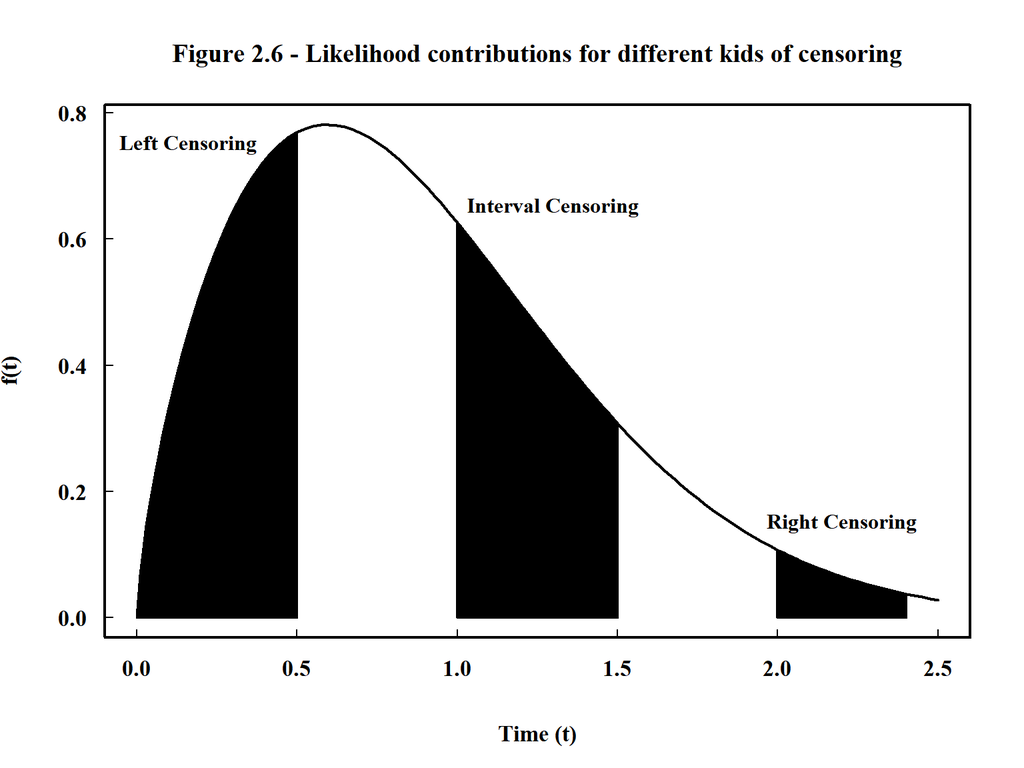

```r
par(family = 'serif', font = 2)

curve(dweibull(x, shape = 1.7, scale = 1),
      lwd = 2,
      las = 1,
      xlim = c(0,2.5),
      xlab = 'Time (t)',
      ylab = 'f(t)',
      main = 'Figure 2.6 - Likelihood contributions for different kids of censoring')

polygon(x = c(seq(0,.5,.01),.5),
        y = c(dweibull(seq(0,.5,.01),shape = 1.7,scale = 1),0),
        col = 1)
polygon(x = c(1,seq(1,1.5,.01),1.5),
        y = c(0,dweibull(seq(1,1.5,.01),shape = 1.7,scale = 1),0),
        col = 1)
polygon(x = c(2,seq(2,2.4,.01),2.4),
        y = c(0,dweibull(seq(2,2.4,.01),shape = 1.7,scale = 1),0),
        col = 1)

text(x = c(.16,1.3,2.2),
     y = c(.75,.65,.15),
     labels = c('Left Censoring',
                'Interval Censoring',
                'Right Censoring'))
```

- Table 2.2 expresses the contribution of each observation in terms of the underlying failure distribution

| Censoring type | Range | Likelihood |
| --- | --- | --- |
| $d_{i}$ observations interval censored in $t_{i-1}$ and $t_{i}$ | $t_{i-1}<T\le t_{i}$ | $[F(t_{i})-F(t_{i-1})]^{d_{i}}$ |
| $l_{i}$ observations left censored at $t_{i}$ | $T\le t_{i}$ | $[F(t_{i})]^{l_{i}}$ |
| $r_{i}$ observations right censored at $t_{i}$ | $T>t_{i}$ | $[1-F(t_{i})]^{r_{i}}$ |

- Using the expressions in Table 2.2, the total likelihood for a data set containing exact observations, and arbitrarily censored observations is expressed as
  $$\begin{aligned}
  \mathscr{L}(\theta|t_1,\ldots,t_n)
  &=C\prod_{i=1}^{n} \mathscr{L}(\theta|t_i)\\
  &=C\prod_{i=1}^{m+1}[F(t_{i})]^{l_{i}}[F(t_{i})-F(t_{i-1})]^{d_{i}}[1-F(t_{i})]^{r_{i}}
  \end{aligned}$$
- where $n = \sum_{j=1}^{m+1}(d_{j}+r_{j}+l_{j})$

# 2.4.4 - Form Of The Constant Term $C$

- In general, the multinomial constant term $C$ does not effect the value of $\boldsymbol{\hat{\theta}}_{_{MLE}}$ that maximizes the total likelihood
- For most models used in this course $C$ may be considered a proportionality constant (i.e. $C=1$)
  $$\mathcal{C}=\frac{n!}{d_1!...d_{m+1}!}$$

# 2.4.5 - Likelihood Terms For General Reliability Data

- This section presents a more general expression for the total likelihood function when
  - The intervals in which a failure occurs overlap
  - The union of the intervals do not cover the entire time line $(0,\infty)$
- In this course, the form of $\mathscr{L}$ given in equation 2.14 is sufficient

# 2.4.6 - Other Likelihood Terms

- This section presents an even more general expression for the total likelihood function when
  - Censoring occurs at random times within the intervals according to $f_{c}(t)$
  - The distributions represented by $f_{c}(t)$ and $f(t)$ are independent
- This type of censoring can occur if multiple failure modes are present in the unit under test
- Multiple failure modes with be considered in Chapter 15
- Truncated data will be discussed in Chapter 11